# Project - Exploration of TMDb Movie Dataset

Table of Contents

. Introduction . Data Wrangling . Exploratory Data Analysis . Conclusion

Introduction This project entails the investigation of a dataset taken from the Movie Database(TMDb), "a community built movie and TV database "(https://www.kaggle.com/tmdb/tmdb-movie-metadata). Apiece row links to a movie and includes a range of data about each film.Pertinent data to be used in the subsequent analysis include the following variables: . original_tile . genres . release_date . release_year

In this report, I explore the following question . What Year has higest release of movies? . What Movie is with highest and lowest profit? . Which is Highest Budget movie and Lowest Budget Movies? . What Movies generated Highest Revenue and Lowest Revenue? . Which is Longest Runtime Movie and Shortest Runtime Movie? . Which is Highest Rated movie and Lowest Rated Movie? . Which Year has Highest Profit Rate? . what Movie duration liked by customers based on popularity? . Which is Year by Year Average Runtime of Movies? . What relationship can be established between variables such as revenue,popularity,budget,runtime and profit? . Which Movie Genre has the Highest Release? . Can we provide the list of most popular genres from year to year? . Can we provide the list of top 20 directors that direct maximum movies?

Throughout my analysis, profit(as calculated by subtracting each film's budget from its revenue) will be the dependent variable,while release year, release date , budget, and genre will be the independent variables.

```python
# setting up import statement for planned packages to be used
# strategize to use

import pandas as pd
import numpy as np
import seaborn as sns
import matplotlib.pyplot as plt
%matplotlib inline
```

Data Wrangling This dataset was loaded, assessed and properly cleaned based on observation and analysis taken into cognisance the documentation and justification of all procedues used

```python
# load dataset
df4 = pd.read_csv('tmdb-movies.csv')
df4.info()
```

```
<class 'pandas.core.frame.DataFrame'>
RangeIndex: 10866 entries, 0 to 10865
Data columns (total 21 columns):
 #   Column                Non-Null Count  Dtype
---  ------                --------------  -----
 0   id                    10866 non-null  int64
 1   imdb_id               10856 non-null  object
 2   popularity            10866 non-null  float64
 3   budget                10866 non-null  int64
 4   revenue               10866 non-null  int64
 5   original_title        10866 non-null  object
 6   cast                  10790 non-null  object
 7   homepage              2936 non-null   object
 8   director              10822 non-null  object
 9   tagline               8042 non-null   object
 10  keywords              9373 non-null   object
 11  overview              10862 non-null  object
 12  runtime               10866 non-null  int64
 13  genres                10843 non-null  object
 14  production_companies  9836 non-null   object
 15  release_date          10866 non-null  object
 16  vote_count            10866 non-null  int64
 17  vote_average          10866 non-null  float64
 18  release_year          10866 non-null  int64
 19  budget_adj            10866 non-null  float64
 20  revenue_adj           10866 non-null  float64
dtypes: float64(4), int64(6), object(11)
memory usage: 1.7+ MB
```

The cell above provides us with information about datatype and variables

```python
# print first five rows
df4.head()
```

|  | id | imdb_id | popularity | budget | revenue | original_title | cast | homepage | director | tagline | ... | overview | runtime | genres | production_companies | release_date | vote_count | vote_average | release_year | budget_adj | revenue_adj |
| --- | --- | --- | --- | --- | --- | --- | --- | --- | --- | --- | --- | --- | --- | --- | --- | --- | --- | --- | --- | --- | --- |
| 0 | 135397 | tt0369610 | 32.985763 | 150000000 | 1513528810 | Jurassic World | Chris Pratt\|Bryce Dallas Howard\|Irrfan Khan\|Vi... | http://www.jurassicworld.com/ | Colin Trevorrow | The park is open. | ... | Twenty-two years after the events of Jurassic ... | 124 | Action\|Adventure\|Science Fiction\|Thriller | Universal Studios\|Amblin Entertainment\|Legenda... | 6/9/15 | 5562 | 6.5 | 2015 | 1.379999e+08 | 1.392446e+09 |
| 1 | 76341 | tt1392190 | 28.419936 | 150000000 | 378436354 | Mad Max: Fury Road | Tom Hardy\|Charlize Theron\|Hugh Keays-Byrne\|Nic... | http://www.madmaxmovie.com/ | George Miller | What a Lovely Day. | ... | An apocalyptic story set in the furthest reach... | 120 | Action\|Adventure\|Science Fiction\|Thriller | Village Roadshow Pictures\|Kennedy Miller Produ... | 5/13/15 | 6185 | 7.1 | 2015 | 1.379999e+08 | 3.481613e+08 |
| 2 | 262500 | tt2908446 | 13.112507 | 110000000 | 295238201 | Insurgent | Shailene Woodley\|Theo James\|Kate Winslet\|Ansel... | http://www.thedivergentseries.movie/#insurgent | Robert Schwentke | One Choice Can Destroy You | ... | Beatrice Prior must confront her inner demons ... | 119 | Adventure\|Science Fiction\|Thriller | Summit Entertainment\|Mandeville Films\|Red Wago... | 3/18/15 | 2480 | 6.3 | 2015 | 1.012000e+08 | 2.716190e+08 |
| 3 | 140607 | tt2488496 | 11.173104 | 200000000 | 2068178225 | Star Wars: The Force Awakens | Harrison Ford\|Mark Hamill\|Carrie Fisher\|Adam D... | http://www.starwars.com/films/star-wars-episod... | J.J. Abrams | Every generation has a story. | ... | Thirty years after defeating the Galactic Empi... | 136 | Action\|Adventure\|Science Fiction\|Fantasy | Lucasfilm\|Truenorth Productions\|Bad Robot | 12/15/15 | 5292 | 7.5 | 2015 | 1.839999e+08 | 1.902723e+09 |
| 4 | 168259 | tt2820852 | 9.335014 | 190000000 | 1506249360 | Furious 7 | Vin Diesel\|Paul Walker\|Jason Statham\|Michelle ... | http://www.furious7.com/ | James Wan | Vengeance Hits Home | ... | Deckard Shaw seeks revenge against Dominic Tor... | 137 | Action\|Crime\|Thriller | Universal Pictures\|Original Film\|Media Rights ... | 4/1/15 | 2947 | 7.3 | 2015 | 1.747999e+08 | 1.385749e+09 |

5 rows × 21 columns

```python
# printing last five rows
df4.tail()
```

|  | id | imdb_id | popularity | budget | revenue | original_title | cast | homepage | director | tagline | ... | overview | runtime | genres | production_companies | release_date | vote_count | vote_average | release_year | budget_adj | revenue_adj |
| --- | --- | --- | --- | --- | --- | --- | --- | --- | --- | --- | --- | --- | --- | --- | --- | --- | --- | --- | --- | --- | --- |
| 10861 | 21 | tt0060371 | 0.080598 | 0 | 0 | The Endless Summer | Michael Hynson\|Robert August\|Lord 'Tally Ho' B... | NaN | Bruce Brown | NaN | ... | The Endless Summer, by Bruce Brown, is one of ... | 95 | Documentary | Bruce Brown Films | 6/15/66 | 11 | 7.4 | 1966 | 0.000000 | 0.0 |
| 10862 | 20379 | tt0060472 | 0.065543 | 0 | 0 | Grand Prix | James Garner\|Eva Marie Saint\|Yves Montand\|Tosh... | NaN | John Frankenheimer | Cinerama sweeps YOU into a drama of speed and ... | ... | Grand Prix driver Pete Aron is fired by his te... | 176 | Action\|Adventure\|Drama | Cherokee Productions\|Joel Productions\|Douglas ... | 12/21/66 | 20 | 5.7 | 1966 | 0.000000 | 0.0 |
| 10863 | 39768 | tt0060161 | 0.065141 | 0 | 0 | Beregis Avtomobilya | Innokentiy Smoktunovskiy\|Oleg Efremov\|Georgi Z... | NaN | Eldar Ryazanov | NaN | ... | An insurance agent who moonlights as a carthie... | 94 | Mystery\|Comedy | Mosfilm | 1/1/66 | 11 | 6.5 | 1966 | 0.000000 | 0.0 |
| 10864 | 21449 | tt0061177 | 0.064317 | 0 | 0 | What's Up, Tiger Lily? | Tatsuya Mihashi\|Akiko Wakabayashi\|Mie Hama\|Joh... | NaN | Woody Allen | WOODY ALLEN STRIKES BACK! | ... | In comic Woody Allen's film debut, he took the... | 80 | Action\|Comedy | Benedict Pictures Corp. | 11/2/66 | 22 | 5.4 | 1966 | 0.000000 | 0.0 |
| 10865 | 22293 | tt0060666 | 0.035919 | 19000 | 0 | Manos: The Hands of Fate | Harold P. Warren\|Tom Neyman\|John Reynolds\|Dian... | NaN | Harold P. Warren | It's Shocking! It's Beyond Your Imagination! | ... | A family gets lost on the road and stumbles up... | 74 | Horror | Norm-Iris | 11/15/66 | 15 | 1.5 | 1966 | 127642.279154 | 0.0 |

5 rows × 21 columns

```python
# magnitude of dataset
df4.shape
```

```
(10866, 21)
```

the axis above has 10866 records and 21 columns form the dataset

Remark from dataset The unit of currency for columns such as 'budget', 'revenue', 'budget_adj', 'revenue_adj'was not given as such i am assuming this unit of currency is us dollars for this dataset Budget and revenue has a value of 0 for lots of movies in this dataset

```python
df4.describe()
```

|  | id | popularity | budget | revenue | runtime | vote_count | vote_average | release_year | budget_adj | revenue_adj |
| --- | --- | --- | --- | --- | --- | --- | --- | --- | --- | --- |
| count | 10866.000000 | 10866.000000 | 1.086600e+04 | 1.086600e+04 | 10866.000000 | 10866.000000 | 10866.000000 | 10866.000000 | 1.086600e+04 | 1.086600e+04 |
| mean | 66064.177434 | 0.646441 | 1.462570e+07 | 3.982332e+07 | 102.070863 | 217.389748 | 5.974922 | 2001.322658 | 1.755104e+07 | 5.136436e+07 |
| std | 92130.136561 | 1.000185 | 3.091321e+07 | 1.170035e+08 | 31.381405 | 575.619058 | 0.935142 | 12.812941 | 3.430616e+07 | 1.446325e+08 |
| min | 5.000000 | 0.000065 | 0.000000e+00 | 0.000000e+00 | 0.000000 | 10.000000 | 1.500000 | 1960.000000 | 0.000000e+00 | 0.000000e+00 |
| 25% | 10596.250000 | 0.207583 | 0.000000e+00 | 0.000000e+00 | 90.000000 | 17.000000 | 5.400000 | 1995.000000 | 0.000000e+00 | 0.000000e+00 |
| 50% | 20669.000000 | 0.383856 | 0.000000e+00 | 0.000000e+00 | 99.000000 | 38.000000 | 6.000000 | 2006.000000 | 0.000000e+00 | 0.000000e+00 |
| 75% | 75610.000000 | 0.713817 | 1.500000e+07 | 2.400000e+07 | 111.000000 | 145.750000 | 6.600000 | 2011.000000 | 2.085325e+07 | 3.369710e+07 |
| max | 417859.000000 | 32.985763 | 4.250000e+08 | 2.781506e+09 | 900.000000 | 9767.000000 | 9.200000 | 2015.000000 | 4.250000e+08 | 2.827124e+09 |

An explicit understanding into the spread of the dataset is obtained from the cell above

```python
df4.isnull().sum()
```

```
id                         0
imdb_id                   10
popularity                 0
budget                     0
revenue                    0
original_title             0
cast                      76
homepage                7930
director                  44
tagline                 2824
keywords                1493
overview                   4
runtime                    0
genres                    23
production_companies    1030
release_date               0
vote_count                 0
vote_average               0
release_year               0
budget_adj                 0
revenue_adj                0
dtype: int64
```

Cell above shows all variables and those of utmost interest to us concerning our analysis. These variables such as popularity,revenue,budget,release_date,release_year are without flows as such filling NaN values in our dataset with a 0 is of paramount importance.

```python
# fill null with zero via 'fillna' function
# some rows contain string values so i will not update with zero
df4.fillna(0)
print()
```

```python
# duplicate checks
df4.duplicated().any()
```

```
True
```

Valuation . Dataset contains Null Values . Datatype for release date should be converted from string to datetime . There are duplicates that need to be dropped . There are dependent and independent variables in columns

Removing duplicates

```python
# count duplicate elements
sum(df4.duplicated())
```

```
1
```

```python
# Droping duplicates row
df4.drop_duplicates(inplace=True)
df4.shape
```

```
(10865, 21)
```

Converting Datatype from Release Date to Datetime

```python
# Convert datatype
df4['release_date'] = pd.to_datetime(df4['release_date'])
# concfirming conversion
df4['release_date'].head()
```

```
0   2015-06-09
1   2015-05-13
2   2015-03-18
3   2015-12-15
4   2015-04-01
Name: release_date, dtype: datetime64[ns]
```

Remove unwanted columns not required for observation

```python
# remove columns and rows
df4.drop(['budget_adj','revenue_adj','overview','imdb_id','homepage','tagline'], axis=1, inplace=True)
# check to confirm if changes have been implemented
df4.shape
```

```
(10865, 15)
```

```python
# droping rows not needed in the budget colum
df4[(df4['budget']==0)].shape[0]
```

```
5696
```

```python
# droping rows not needed in the revenue column
df4[(df4['revenue']==0)].shape[0]
```

```
6016
```

Exploratory Data Analysis Having cleaned the dataset properly, it is now time to create visualization with the aim of addressing the research questions that was posed in the introductory phase of this project

i. What Year has higest release of movies

```
release_year
2011    540
2012    588
2013    659
2014    700
2015    629
Name: id, dtype: int64
```

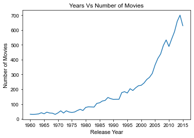

```python
# group the year and count movie number
info = df4.groupby('release_year').count()['id']
print(info.tail())
# create group of the info based on release year counting overall number of movie and plot
df4.groupby('release_year').count()['id'].plot(xticks = np.arange(1960,2016,5))
# seting figure size and labels
sns.set(rc={'figure.figsize':(8,4)})
plt.xlabel('Release Year', fontsize=11)
plt.ylabel('Number of Movies', fontsize=11)
plt.title("Years Vs Number of Movies", fontsize=12)
# set style
sns.set_style("whitegrid")
```

We can see the pattern thus far that the highest number of movies was produced in year 2014 with 700 followed by 2013 with 659 while 2015 came running with 629.

ii. What Movie is with highest and lowest profit

```python
# compute the profit per movie
# create 'Profit' as a new column in the DataFrame
df4['Profit'] = df4['revenue'] - df4['budget']
```

```python
# use 'idmin' function to discover the index for movie with Lowest Profit
# use 'idmax' function to discover the index for movie with Highest Profit
# print row linked to the index
def find_minmax(x):
    # use 'idmin' function to discover the index for movie with Lowest Profit
    min_index = df4[x].idxmin()
    # use 'idmax' function to discover the index for movie with Highest Profit
    high_index = df4[x].idxmax()
    high = pd.DataFrame(df4.loc[high_index,:])
    low = pd.DataFrame(df4.loc[min_index,:])

    # print high profit movie and low profit movie
    print("movie with Highest"+x+":",df4['original_title'][high_index])
    print("movie with Lowest"+x+":",df4['original_title'][min_index])
    return pd.concat([high,low],axis = 1)

# call the find_minmax function.
find_minmax('Profit')
```

```
movie with HighestProfit: Avatar
movie with LowestProfit: The Warrior's Way
```

|  | 1386 | 2244 |
| --- | --- | --- |
| id | 19995 | 46528 |
| popularity | 9.432768 | 0.25054 |
| budget | 237000000 | 425000000 |
| revenue | 2781505847 | 11087569 |
| original_title | Avatar | The Warrior's Way |
| cast | Sam Worthington\|Zoe Saldana\|Sigourney Weaver\|S... | Kate Bosworth\|Jang Dong-gun\|Geoffrey Rush\|Dann... |
| director | James Cameron | Sngmoo Lee |
| keywords | culture clash\|future\|space war\|space colony\|so... | assassin\|small town\|revenge\|deception\|super speed |
| runtime | 162 | 100 |
| genres | Action\|Adventure\|Fantasy\|Science Fiction | Adventure\|Fantasy\|Action\|Western\|Thriller |
| production_companies | Ingenious Film Partners\|Twentieth Century Fox ... | Boram Entertainment Inc. |
| release_date | 2009-12-10 00:00:00 | 2010-12-02 00:00:00 |
| vote_count | 8458 | 74 |
| vote_average | 7.1 | 6.4 |
| release_year | 2009 | 2010 |
| Profit | 2544505847 | -413912431 |

We can see from the above output that Avatar is the movie with Highest Profit of $2.5B while The Warrior's Way made the lowest profit at a loss of $400M

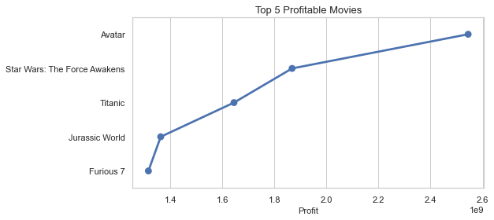

```python
# generate a plot that has highest profit for top 5 movies
# categorize 'Profit' column in downward order and save in new dataframe
info = pd.DataFrame(df4['Profit'].sort_values(ascending = False))
info['original_title'] = df4['original_title']
data = list(map(str,(info['original_title'])))
x = list(data[:5])
y = list(info['Profit'][:5])

# generate a plot using pointplot for profitable top 5 movies
ax=sns.pointplot(x=y,y=x)

# setup figure size
sns.set(rc={'figure.figsize':(8,4)})
# arrange labels and title for the plot
ax.set_xlabel("Profit", fontsize=11)
ax.set_title("Top 5 Profitable Movies", fontsize=13)
sns.set_style("whitegrid")
```

iii. What is Highest Budget movie and Lowest Budget Movies

```python
# look for Highest Budget Movie and Lowest Budget Movie
# recall 'find_minmax' function which was ealier generated
# ensure movie with zero buget is monitored
# for budget column, change zero to NaN
df4['budget'] = df4['budget'].replace(0,np.NaN)
find_minmax('budget')
```

```
movie with Highestbudget: The Warrior's Way
movie with Lowestbudget: Fear Clinic
```

|  | 2244 | 1151 |
| --- | --- | --- |
| id | 46528 | 287524 |
| popularity | 0.25054 | 0.177102 |
| budget | 425000000.0 | 1.0 |
| revenue | 11087569 | 0 |
| original_title | The Warrior's Way | Fear Clinic |
| cast | Kate Bosworth\|Jang Dong-gun\|Geoffrey Rush\|Dann... | Thomas Dekker\|Robert Englund\|Cleopatra Coleman... |
| director | Sngmoo Lee | Robert Hall |
| keywords | assassin\|small town\|revenge\|deception\|super speed | phobia\|doctor\|fear |
| runtime | 100 | 95 |
| genres | Adventure\|Fantasy\|Action\|Western\|Thriller | Horror |
| production_companies | Boram Entertainment Inc. | Dry County Films\|Anchor Bay Entertainment\|Movi... |
| release_date | 2010-12-02 00:00:00 | 2014-10-31 00:00:00 |
| vote_count | 74 | 15 |
| vote_average | 6.4 | 4.1 |
| release_year | 2010 | 2014 |
| Profit | -413912431 | -1 |

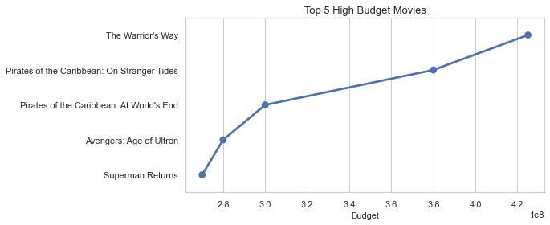

```python
# generate a plot that has highest budget for top 5 movies
# categorize 'budget' column in downward order and save in new dataframe
info = pd.DataFrame(df4['budget'].sort_values(ascending = False))
info['original_title'] = df4['original_title']
data = list(map(str,(info['original_title'])))


# remove top 5 budget movies from list and dataframe
x = list(data[:5])
y = list(info['budget'][:5])

# setup figure size
ax = sns.pointplot(x=y,y=x)
sns.set(rc={'figure.figsize':(8,4)})
# arrange labels and title for the plot
ax.set_xlabel("Budget", fontsize=11)
ax.set_title("Top 5 High Budget Movies", fontsize=13)
sns.set_style("whitegrid")
```

iv. What Movies generated Highest Revenue and Lowest Revenue

```python
# look for movie that produced highest and lowest revenue
# recall 'find_minmax' function earlier generated
find_minmax('revenue')
```

```
movie with Highestrevenue: Avatar
movie with Lowestrevenue: Wild Card
```

|  | 1386 | 48 |
| --- | --- | --- |
| id | 19995 | 265208 |
| popularity | 9.432768 | 2.93234 |
| budget | 237000000.0 | 30000000.0 |
| revenue | 2781505847 | 0 |
| original_title | Avatar | Wild Card |
| cast | Sam Worthington\|Zoe Saldana\|Sigourney Weaver\|S... | Jason Statham\|Michael Angarano\|Milo Ventimigli... |
| director | James Cameron | Simon West |
| keywords | culture clash\|future\|space war\|space colony\|so... | gambling\|bodyguard\|remake |
| runtime | 162 | 92 |
| genres | Action\|Adventure\|Fantasy\|Science Fiction | Thriller\|Crime\|Drama |
| production_companies | Ingenious Film Partners\|Twentieth Century Fox ... | Current Entertainment\|Lionsgate\|Sierra / Affin... |
| release_date | 2009-12-10 00:00:00 | 2015-01-14 00:00:00 |
| vote_count | 8458 | 481 |
| vote_average | 7.1 | 5.3 |
| release_year | 2009 | 2015 |
| Profit | 2544505847 | -30000000 |

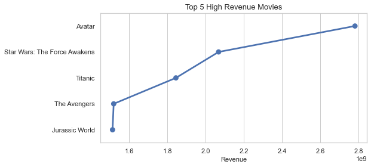

```python
# generate a plot that has highest revenue for top 5 movies
# categorize 'revenue' column in downward order and save in new dataframe
info = pd.DataFrame(df4['revenue'].sort_values(ascending = False))
info['original_title'] = df4['original_title']
data = list(map(str,(info['original_title'])))


# remove top 5 revenue movies from list and dataframe
x = list(data[:5])
y = list(info['revenue'][:5])

# setup figure size
ax = sns.pointplot(x=y,y=x)
sns.set(rc={'figure.figsize':(8,4)})
# arrange labels and title for the plot
ax.set_xlabel("Revenue", fontsize=11)
ax.set_title("Top 5 High Revenue Movies", fontsize=13)
sns.set_style("whitegrid")
```

v. Which is Longest Runtime Movie and Shortest Runtime Movie

```python
# look for Highest Runtime Movie and Lowest Runtime Movie
# recall 'find_minmax' function which was ealier generated
# ensure movie with zero runtime is monitored as it not okay since dataset contains data like this
# for runtime column, change zero to NaN
df4['runtime'] = df4['runtime'].replace(0,np.NaN)
find_minmax('runtime')
```

```
movie with Highestruntime: The Story of Film: An Odyssey
movie with Lowestruntime: Fresh Guacamole
```

|  | 3894 | 4883 |
| --- | --- | --- |
| id | 125336 | 142563 |
| popularity | 0.006925 | 0.078472 |
| budget | NaN | NaN |
| revenue | 0 | 0 |
| original_title | The Story of Film: An Odyssey | Fresh Guacamole |
| cast | Mark Cousins\|Jean-Michel Frodon\|Cari Beauchamp... | NaN |
| director | Mark Cousins | PES |
| keywords | cinema\|nouvelle vague\|hindi cinema\|cinema novo... | NaN |
| runtime | 900.0 | 2.0 |
| genres | Documentary | Animation |
| production_companies | NaN | NaN |
| release_date | 2011-09-03 00:00:00 | 2012-03-02 00:00:00 |
| vote_count | 14 | 29 |
| vote_average | 9.2 | 7.9 |
| release_year | 2011 | 2012 |
| Profit | 0 | 0 |

The output above shows the movie 'The Story of Film:An Odyssey' with highest runtime of 900min which is approximately 15hrs; this should probably be a series while the movie 'Fresh Guacamole' has the shortest runtime of 2min; this is indeed a very short movie

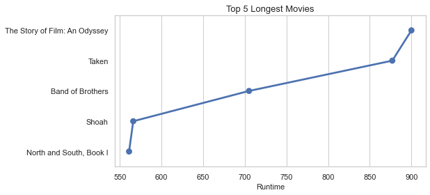

```python
# create a plot that has longest runtime for top 5 movies
# categorize 'runtime' column in downward order and save in new dataframe
info = pd.DataFrame(df4['runtime'].sort_values(ascending = False))
info['original_title'] = df4['original_title']
data = list(map(str,(info['original_title'])))


# remove top 5 longest movies from list and dataframe
x = list(data[:5])
y = list(info['runtime'][:5])

# setup figure size
ax = sns.pointplot(x=y,y=x)
sns.set(rc={'figure.figsize':(8,4)})
# arrange labels and title for the plot
ax.set_xlabel("Runtime", fontsize=11)
ax.set_title("Top 5 Longest Movies", fontsize=13)
sns.set_style("whitegrid")
```

vi. Which is Highest Rated movie and Lowest Rated Movie

```python
# look for movie with most vote and least vote
# recall 'find_minmax' function generated eailer by using 'vote_average' as arguement
find_minmax('vote_average')
```

```
movie with Highestvote_average: The Story of Film: An Odyssey
movie with Lowestvote_average: Transmorphers
```

|  | 3894 | 7772 |
| --- | --- | --- |
| id | 125336 | 25055 |
| popularity | 0.006925 | 0.12112 |
| budget | NaN | NaN |
| revenue | 0 | 0 |
| original_title | The Story of Film: An Odyssey | Transmorphers |
| cast | Mark Cousins\|Jean-Michel Frodon\|Cari Beauchamp... | Matthew Wolf\|Amy Weber\|Shaley Scott\|Eliza Swen... |
| director | Mark Cousins | Leigh Scott |
| keywords | cinema\|nouvelle vague\|hindi cinema\|cinema novo... | futuristic |
| runtime | 900.0 | 86.0 |
| genres | Documentary | Action\|Adventure\|Science Fiction |
| production_companies | NaN | Asylum, The |
| release_date | 2011-09-03 00:00:00 | 2007-06-26 00:00:00 |
| vote_count | 14 | 10 |
| vote_average | 9.2 | 1.5 |
| release_year | 2011 | 2007 |
| Profit | 0 | 0 |

Here, the output shows the movie 'The Story of Film:An Odyssey' as the most rated with 92% while the movie 'Transmorphers' as the least rated with 15%

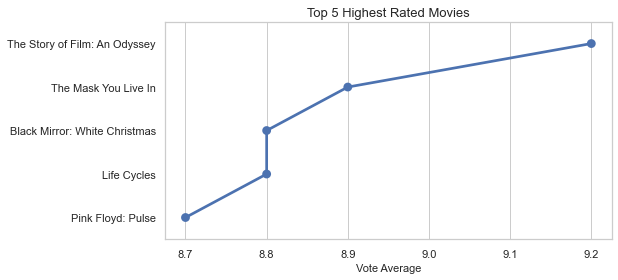

```python
# create a plot with top 5 highest rated movies
# categorize 'vote_average' column in downward order and save in new dataframe
info = pd.DataFrame(df4['vote_average'].sort_values(ascending = False))
info['original_title'] = df4['original_title']
data = list(map(str,(info['original_title'])))


# remove top 5 longest movies from list and dataframe
x = list(data[:5])
y = list(info['vote_average'][:5])

# setup figure size
ax = sns.pointplot(x=y,y=x)
sns.set(rc={'figure.figsize':(8,4)})
# arrange labels and title for the plot
ax.set_xlabel("Vote Average", fontsize=11)
ax.set_title("Top 5 Highest Rated Movies", fontsize=13)
sns.set_style("whitegrid")
```

vii. Which Year is with Highest Profit Rate

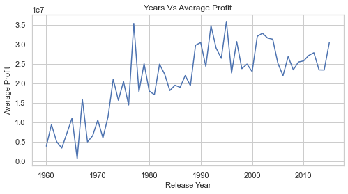

```python
# Profit analysis is done for movie per year
# plot the avarage profit of movies per year
# create group of data based on release_year , finding mean profit and plot
df4.groupby('release_year')['Profit'].mean().plot()

# seting figure size and labels
sns.set(rc={'figure.figsize':(8,4)})
plt.xlabel('Release Year', fontsize=11)
plt.ylabel('Average Profit', fontsize=11)
plt.title("Years Vs Average Profit", fontsize=12)
# set style
sns.set_style("darkgrid")
```

viii. What Movie duration liked by customers based on popularity

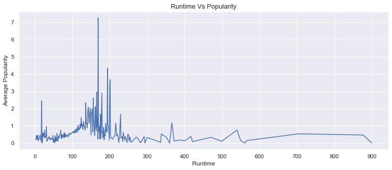

```python
# recall gyroupby function by grouping data based on their respective runtime
# crrate plot with popularity and look for which movie duration is most popular
# create group of the data based on runtime and look for mean, popularity and plot
df4.groupby('runtime')['popularity'].mean().plot(figsize=(13,5),xticks=np.arange(0,1000,100))

# seting figure size and labels
sns.set(rc={'figure.figsize':(8,4)})
plt.xlabel('Runtime', fontsize=12)
plt.ylabel('Average Popularity', fontsize=12)
plt.title("Runtime Vs Popularity", fontsize=13)
# set style
sns.set_style("darkgrid")
```

Plot above shows that movie with runtime in the range of 100-200 have the highest popularity as compared to others

ix. Which is Year by Year Average Runtime of Movies

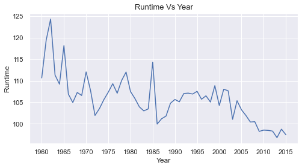

```python
# look for year by year runtime of movies
# create group of data based on release_year, look for mean and plot
df4.groupby('release_year').mean()['runtime'].plot(xticks=np.arange(1960,2016,5))

# seting figure size and labels
sns.set(rc={'figure.figsize':(8,4)})
plt.xlabel('Year', fontsize=12)
plt.ylabel('Runtime', fontsize=12)
plt.title("Runtime Vs Year", fontsize=13)
# set style
sns.set_style("whitegrid")
```

The plot above shows a trend that movie duration decrease year by year . This is very correct as most people do not have that patience to sit down and watch movies with very long duration ; this equally transcend to the reason while the average runtime for movie is 100min.

x. Relationship of how Revenue and Popularity varies from Budget and Runtime;Popularity dependability on Profit

```
correlation Between Revenue And Budget: 0.6885561524636727
```

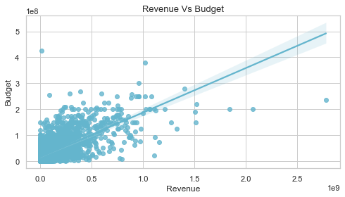

```python
# look for how revenue changes based on budget
# generate scatter diagram using 'regplot' between 'revenue' and 'budget'
ax = sns.regplot(x=df4['revenue'], y=df4['budget'], color='c')

# seting figure size and labels
sns.set(rc={'figure.figsize':(8,4)})
plt.xlabel('Revenue', fontsize=12)
plt.ylabel('Budget', fontsize=12)
plt.title("Revenue Vs Budget", fontsize=13)
# set style
sns.set_style("whitegrid")

# look for correlation between the variables
# convert zero to NAN in budget and revenue column for the correct computation
df4['budget'] = df4['budget'].replace(0,np.NAN)
df4['revenue'] = df4['revenue'].replace(0,np.NAN)
df4['Profit'] = df4['Profit'].replace(0,np.NAN)

# find correlation using 'corr()' function
data_corr = df4.corr()
print("correlation Between Revenue And Budget:",data_corr.loc['revenue','budget'])
```

```
correlation Between Budget And Profit: 0.5383810819019572
```

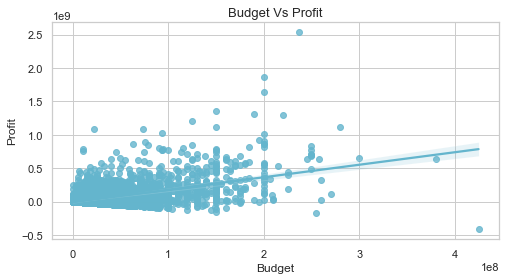

```python
# look at how profit change based on budget
# create scatter diagram using 'regplot' between 'budget' and 'Profit'
ax = sns.regplot(x=df4['budget'], y=df4['Profit'], color='c')

# seting figure size and labels
sns.set(rc={'figure.figsize':(8,4)})
plt.xlabel('Budget', fontsize=12)
plt.ylabel('Profit', fontsize=12)
plt.title("Budget Vs Profit", fontsize=13)
# set style
sns.set_style("whitegrid")

# find correlation using 'corr()' function
data_corr = df4.corr()
print("correlation Between Budget And Profit:",data_corr.loc['budget','Profit'])
```

```
correlation Between Vote Average And Release Year: -0.11757558609467468
```

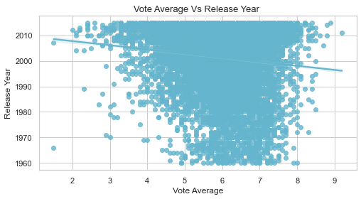

```python
# look for how average vote change based on release year
# create scatter diagram using 'regplot' between 'release year' and 'vote average'
ax = sns.regplot(x=df4['vote_average'], y=df4['release_year'], color='c')

# seting figure size and labels
sns.set(rc={'figure.figsize':(8,4)})
plt.xlabel('Vote Average', fontsize=12)
plt.ylabel('Release Year', fontsize=12)
plt.title("Vote Average Vs Release Year ", fontsize=13)
# set style
sns.set_style("whitegrid")

# find correlation using 'corr()' function
data_corr = df4.corr()
print("correlation Between Vote Average And Release Year:",data_corr.loc['vote_average','release_year'])
```

```
correlation Between Popularity And Profit: 0.6159162443059019
```

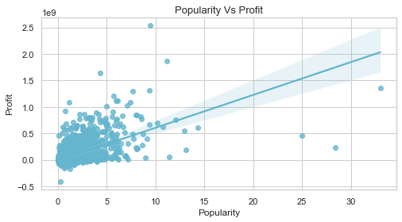

```python
# look for how Popularity change based on profit
# create scatter diagram using 'regplot' between 'Popularity' and 'Profit'
ax = sns.regplot(x=df4['popularity'], y=df4['Profit'], color='c')

# seting figure size and labels
sns.set(rc={'figure.figsize':(8,4)})
plt.xlabel('Popularity', fontsize=12)
plt.ylabel('Profit', fontsize=12)
plt.title("Popularity Vs Profit", fontsize=13)
# set style
sns.set_style("whitegrid")

# find correlation using 'corr()' function
data_corr = df4.corr()
print("correlation Between Popularity And Profit:",data_corr.loc['popularity','Profit'])
```

The output from the all the scatter plot above provide su with these insights: 1.Revenue Vs Budget: Both variables have positive correlation with a value of 0.69. This implies that movies with greater investment produces greater revenue 2.Budget Vs Profit: This variables have positive correlation with value of 0.54. this trend is telling us that higher investment produces higher profit 3.Vote Average Vs Release Year: Both variables have negative correlation of -0.12. This implies that movie rating does not depend on the release year 4.Popularity Vs Profit: Popularity and profit have positive correlation with value of 0.62. This tells us that movies with high popularity tend to generate higher profit. this I believe is true.

xi.Which Movie Genre has the highest release

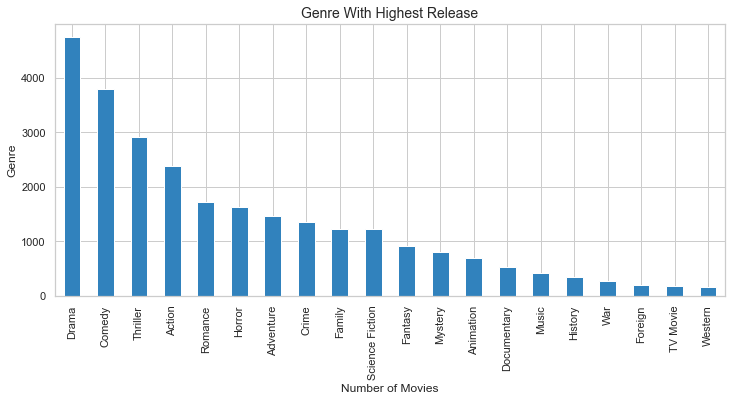

```python
# generate a function to split string and each genre count is return
def count_genre(x):
    # concatenate all the genre rows
    data_plot = df4[x].str.cat(sep = '|')
    data = pd.Series(data_plot.split('|'))
    # each genre is counted and return
    info = data.value_counts(ascending=False)
    return info

# make the function for genre of each movie
total_genre_movies = count_genre('genres')
# plot bar using plot function 'genre Vs number of movies'
total_genre_movies.plot(kind='bar',figsize = (12,5),fontsize=11,colormap='tab20c')

# setup labels and title of plot
plt.xlabel('Number of Movies',fontsize=12)
plt.ylabel('Genre',fontsize=12)
plt.title("Genre With Highest Release",fontsize=14)
sns.set_style("darkgrid")
```

The bar chart above point to the fact that the Genre 'Drama' has the highest release of movies with 4790 while Comedy is second at 3794 and Thriller at 2908

xi.Can we provide the list of most popular genres from year to year

```python
# map entire rows of genre in a list
genre_details = list(map(str,(df4['genres'])))
genre = ['Adventure','Science Fiction','Fantasy','Crime','Western','Family','nan','Animation','War','Mystery','Romance','TV Movie','Action','Thriller','Comedy','Drama','Foreign','History','Music','Romance','Horror','Documentary']

# create a numpy array of year and popularity which contain entire rows of release_year and popularity columns
year = np.array(df4['release_year'])
popularity = np.array(df4['popularity'])

# create null dataframe whose columns are years and index are genres
popularity_df = pd.DataFrame(index = genre, columns = range(1960,2016))
# convert entire values of the dataframe from NAN to zero
popularity_df = popularity_df.fillna(value=0.0)

z = 0
for i in genre_details:
    split_genre = list(map(str,i.split('|')))
    popularity_df.loc[split_genre, year[z]] = popularity_df.loc[split_genre, year[z]] + popularity[z]
    z+=1
```

```python
# for precise results, compute standard deviation
def calculate_std(x):
    return (x-x.mean())/x.std(ddof=0)

popular_genre = calculate_std(popularity_df)
popular_genre.head()
```

|  | 1960 | 1961 | 1962 | 1963 | 1964 | 1965 | 1966 | 1967 | 1968 | 1969 | ... | 2006 | 2007 | 2008 | 2009 | 2010 | 2011 | 2012 | 2013 | 2014 | 2015 |
| --- | --- | --- | --- | --- | --- | --- | --- | --- | --- | --- | --- | --- | --- | --- | --- | --- | --- | --- | --- | --- | --- |
| Adventure | 0.734965 | 1.334850 | 2.044279 | 1.403240 | 0.571832 | 1.089418 | 0.962023 | 1.793704 | 1.582544 | 1.136712 | ... | 0.606864 | 0.526192 | 0.745615 | 0.991132 | 1.040677 | 0.594199 | 0.738401 | 0.781253 | 1.212951 | 1.664587 |
| Science Fiction | -0.502799 | -0.393443 | -0.654176 | -0.680057 | -0.674191 | -0.914883 | 0.088594 | -0.677128 | 1.498895 | -0.708657 | ... | -0.306308 | -0.318878 | 0.060936 | 0.685980 | -0.122046 | 0.211189 | 0.183863 | 0.596757 | 0.934724 | 1.273918 |
| Fantasy | -0.565257 | -0.781850 | -0.707323 | -0.933995 | -0.004127 | -1.039221 | -0.609473 | -0.749703 | -0.038872 | -0.771230 | ... | 0.050709 | 0.323689 | -0.014094 | 0.173693 | 0.141120 | 0.023566 | 0.072586 | -0.178361 | -0.097676 | -0.310439 |
| Crime | -0.645544 | -0.138880 | -0.195713 | -0.042721 | 0.093619 | -0.566926 | -0.045601 | 0.483025 | 0.230732 | 0.621707 | ... | 0.072622 | 0.303003 | 0.280630 | -0.413033 | -0.190315 | -0.067107 | 0.084129 | 0.363827 | -0.211145 | 0.044463 |
| Western | 0.686680 | -0.623230 | -0.271794 | -0.901087 | -1.023837 | -0.571330 | -0.039599 | -0.819477 | -0.824076 | 1.033728 | ... | -1.069320 | -1.054436 | -1.100164 | -1.145546 | -1.010287 | -1.021046 | -0.898266 | -0.988124 | -0.932967 | -0.758266 |

5 rows × 56 columns

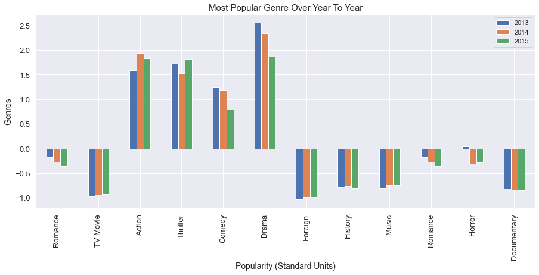

```python
# for standard deviation data, plot bar plot
popular_genre.iloc[10:,53:].plot(kind='bar',figsize = (15,6),fontsize=13)

# setup labels and title of plot
plt.title("Most Popular Genre Over Year To Year",fontsize=15)
plt.xlabel("Popularity (Standard Units)",fontsize=14)
plt.ylabel("Genres",fontsize=14)
sns.set_style("darkgrid")
```

The bar chart above provides us with the list of most popular genres from year to year and Drama is top on the list

xii. Can we provide a list of top 20 directors that directed maximun movies

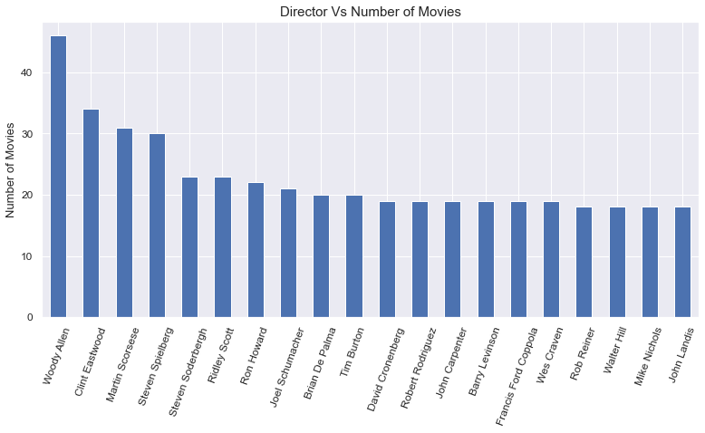

```python
# remember 'count_genre' function made earlier for spliting and counting genre
# so as to count number of movies directed by each director
count_director_movies = count_genre('director')

# plotting bar plot
count_director_movies.iloc[:20].plot(kind='bar',figsize=(13,6),fontsize=12)

# setting up title,labels and plot
plt.title("Director Vs Number of Movies",fontsize=15)
plt.xticks(rotation=70)
plt.ylabel("Number of Movies",fontsize=13)
sns.set_style("darkgrid")
```

Conclusions:

In the first section I examined the year with the highest release of movies. I made my analysis based on the values of 'release_year' and number of movies. I was able to establish the fact that the number of year with the highest release of movies turned out to be 2014 with 700 movies.

Limitation:

1.There is no normalization or exchange rate or currency conversion is considered in the course of this examination thus my analysis is limited to numerical values of revenue 2.During the data cleaning process, I split the data separated by "|" into list for analysis during the data exploration stage. This increased the time taken for computing the results. 3.Dropping missing or Null values from variables of my interest might skew my analysis and could skew inadvertent bias toward the relationship being analyzed etc.